# Коллективная разработка

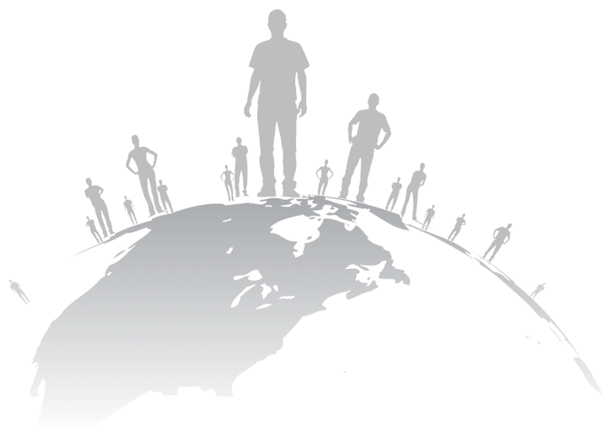

Кирилл Корняков (Itseez, ННГУ)

# Содержание

1. Вспоминаем Git
2. Модели ветвления
3. Модели распределенного рабочего процесса
4. Инспекция кода

# Патчи

> **Патч** (англ. patch — заплатка) — информация, предназначенная для автоматизированного внесения определённых изменений в компьютерные файлы.

**Unified diff format**: `@@ -l,s +l,s @@ optional section heading`

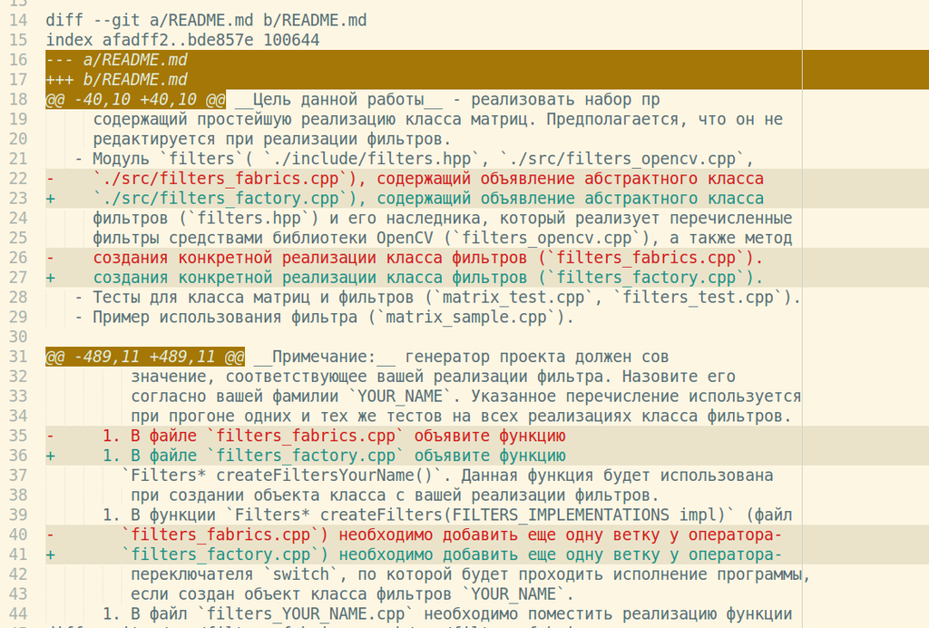

# Патчи

- Патч — это **атомарное изменение** проекта!

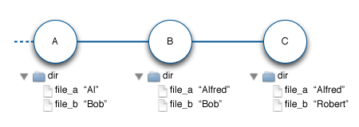

- Патч — это простой текстовый файл, его можно наложить при помощи инструментов (`patch`).
- Патчи, помещенные в VCS называются **commit**.
- Как правило разработчики обмениваются изменениями через VCS.

# История изменений

`ddc4a1d` — **Readme bug fixes.**

```
 - README.md
```

`f9e76e6` — **Remove dummy implementation**

```
 - include/filters.hpp
 - samples/matrix_sample.cpp
 - src/filters_dummy.cpp
 - src/filters_fabrics.cpp
 - test/filters_test.cpp
```

`aa1611b` — **Switch from strings to enums**

```
 - include/filters.hpp
 - samples/matrix_sample.cpp
 - src/filters_fabrics.cpp
 - test/filters_test.cpp
```

`8e8b21b` — **Add some error checking**

```
 - include/filters.hpp
 - src/filters_fabrics.cpp
 - test/filters_test.cpp
```

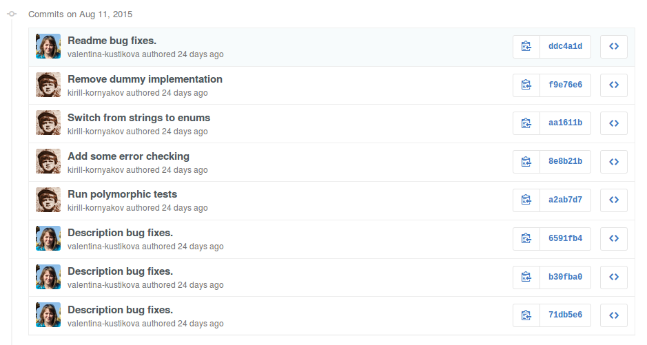

Последовательность патчей — это полная история проекта.

# Multiple branches

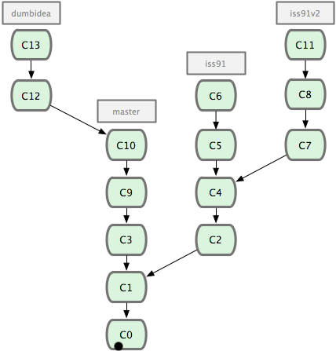

- *Правильно создавать отдельную ветку на каждую логически независимую задачу.*
- Даже у одного разработчика может быть несколько активных веток.
- Долгоживущие ветки — это неправильно, они быстро устаревают.

# Стоит ли использовать VCS в одиночку?

- Статистика и метаинформация работы с файлами
- Удобное резервное копирование
- Извлечение версий кода из прошлого
- Просмотр изменений за любой промежуток времени
- Возможность работать над разными идеями независимо

# Командная работа

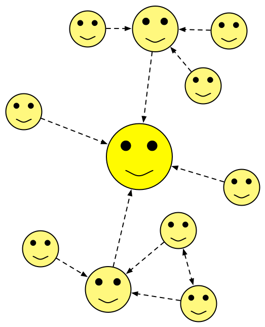

1. Модели ветвления (branching model)
   - Feature Branch Workflow (GitHub Flow)
   - GitFlow
2. Распределенные рабочие процессы (workflow)
   - Centralized
   - Integration Manager
   - Dictator and Lieutenants

# Centralized Repository

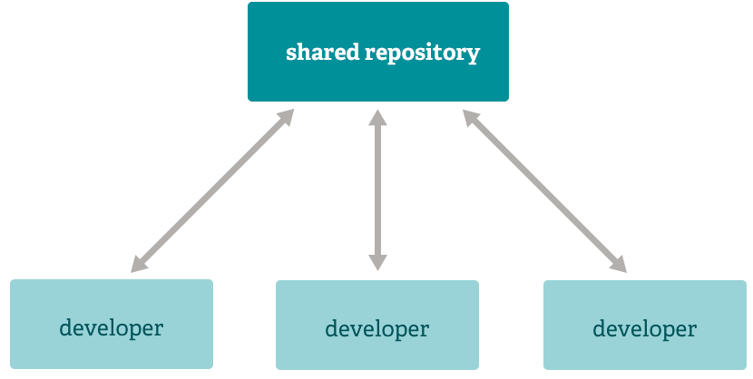

# Feature Branch Workflow

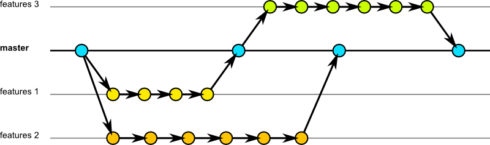

# Feature Branches at GitHub

[figure not shown]

[GitHub Flow](http://scottchacon.com/2011/08/31/github-flow.html)

# Git Flow

A successful Git branching model ([link](http://nvie.com/posts/a-successful-git-branching-model))

# Centralized Workflow

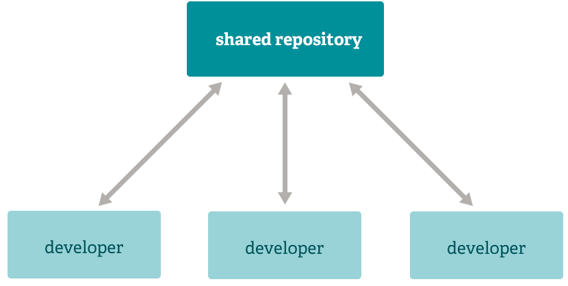

Плюсы и минусы данного подхода?

# Integration Manager Workflow

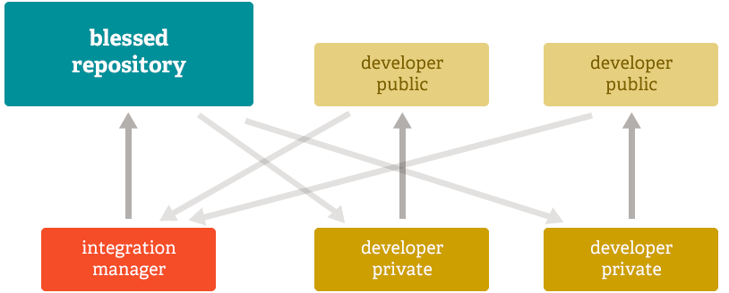

Плюсы и минусы данного подхода?

# Dictator and Lieutenants Workflow

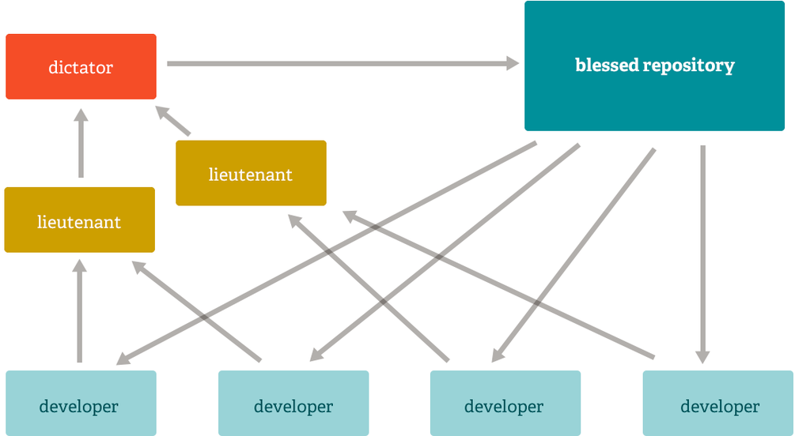

# Triangular Workflow (GitHub)

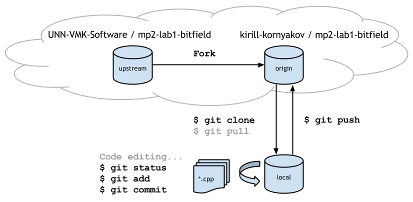

```bash
$ cd mp2-lab1-bitfield
$ git remote -v
origin  https://github.com/kirill-kornyakov/mp2-lab1-bitfield.git (fetch)
origin  https://github.com/kirill-kornyakov/mp2-lab1-bitfield.git (push)
upstream  https://github.com/UNN-VMK-Software/mp2-lab1-bitfield.git (fetch)
upstream  https://github.com/UNN-VMK-Software/mp2-lab1-bitfield.git (push)
```

# GitHub Pull Request

[figure not shown]

# Code Review at GitHub

[figure not shown]

# Code Review at GitHub

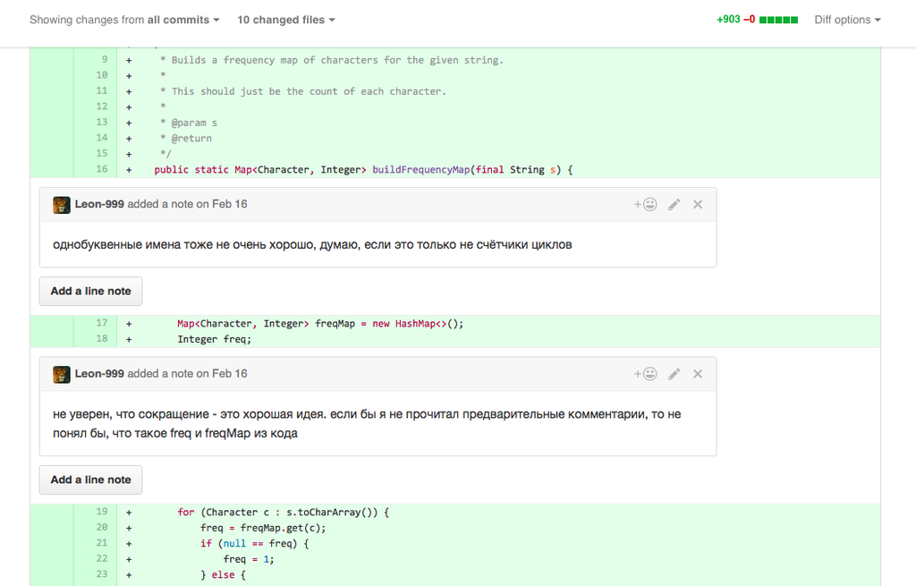

# Community Contributions

[figure not shown]

# GitHub Flow

Anything in the `master` branch is deployable.

1. Create branch
   - To work on something new, create a descriptively named branch off of `master` (ie: `new-oauth2-scopes`).
2. Develop in branch
   - Commit to that branch locally and regularly push your work to the same named branch on the server.
3. Open a pull request (ask for review)
   - When you need feedback or help, or you think the branch is ready for merging, open a pull request.
4. Merge after review
   - After someone else has reviewed and signed off on the feature, you can merge it into `master`.
5. Deploy
   - Once it is merged and pushed to `master`, you can and *should* deploy immediately.

# GitHub Flow в командах Git

```bash
# Check that origin and upstream repositories are correctly defined
$ git remote -v

# Get the latest sources from the upstream repository
$ git remote update

# Checkout a new topic branch for development
$ git checkout -b adding-new-feature upstream/master

#
# Do some development...
#

# Check your changes
$ git status

# Commit your changes
$ git commit -a -m "Added a new feature"

# Push your changes to the origin
$ git push origin HEAD
```

# Спасибо!

Вопросы?